# Multi-Scale Spatial Analysis for Nature-Based Urban Heat Island Mitigation

ARFW0501 – Group D Project Report

Authors

Affiliation

Artemi Kurski

MSc Geomatics, TU Delft

Niranjan Pradeep

MSc Geomatics, TU Delft

Darius Floroiu

MSc Geomatics, TU Delft

Henryk Gujda

MSc Geomatics, TU Delft

# Introduction

In the context of rapid urbanisation and climate change, it is increasingly important to understand how cities shape their local climate.

Comparing cities helps us see how differences in urban form influence temperature, environmental quality, and overall liveability. Cities differ in density, land use, building materials, and the amount of green space they contain. These factors strongly affect how heat is absorbed, stored, and released, which leads to noticeable temperature differences between urban areas. A key concept here is the **Urban Heat Island (UHI)** effect, where cities become warmer than their surrounding rural areas. This happens because materials like concrete and asphalt absorb and hold heat, vegetation is limited and cannot provide enough cooling through shade, and human activities such as transport, buildings, and industry release additional heat. Together, these factors increase local temperatures and can lead to higher heat stress, energy use, and air pollution.

Understanding UHI highlights the direct relationship between urban design and local climate. In this context, we aim to investigate how spatial data resolution influences UHI estimation and how urban blue-green infrastructure contributes to temperature mitigation. In light of this we aim to explore the following research question:

How can multi-scale spatial analysis be used to identify locations where nature-based solutions can most effectively mitigate urban heat island effects and what nature-based solutions are suitable on street level?

**City Selection:** To answer the research question, we focus on two case study cities: Rotterdam and Guangzhou. These cities were selected for their similarities in coastal location and economic significance, while also exhibiting distinct urban forms and climates. `Rotterdam`, located in the Netherlands, is known for its modern architecture and extensive port facilities, while `Guangzhou`, in southern China, features a mix of traditional and contemporary urban development. By comparing these two cities, we can gain insights into how different urban designs and green infrastructure strategies impact UHI intensity across varying spatial resolutions.

## Methods

Our methodology relies on a dual - scale approach to understand the urban climate. We analyzed both macro - level administrative boundaries (Dutch *buurten* and Chinese *jiedao*) and micro - level street networks. By sticking entirely to open-source data—primarily OpenStreetMap (OSM) and Landsat satellite imagery, we ensured that the pipeline built for Rotterdam could be directly transferred to Guangzhou without coordinate or data availability issues.

# Getting started

The first step of the analysis involves identifying the required datasets and defining the spatial boundaries of the study area.

For this purpose, **Google Earth Engine (GEE)** was used to access and process the main datasets. These datasets form the basis for the initial setup and help in selecting the relevant neighbourhoods for further analysis.

**1. Land Surface Temperature (LST):** LST was derived from Landsat 8 data in Google Earth Engine. Thermal bands were processed to obtain surface temperature, which was then used to study spatial heat variations across Rotterdam.

**2. NDVI:** Vegetation cover was computed from Landsat 8 spectral bands in Google Earth Engine using the Normalized Difference Vegetation Index (NDVI), providing a measure of urban greenness.

**3. Local Climate Zones (LCZ):** Urban form classification was obtained using the RUBCLIM LCZ dataset available in Google Earth Engine, which categorises urban areas based on built type and land cover characteristics.

**4. Administrative boundaries:** Municipal and neighbourhood boundaries for Rotterdam were taken from the `CBS Wijken en Buurten 2025 GeoPackage`, used to define the spatial extent of the study area.

**5. Street network:** The pedestrian street network was extracted from OpenStreetMap using the `osmnx` library, and used for analysing urban connectivity and spatial structure.

# Analysis Workflow

#### Pipeline overview

1

**Data extraction** — Raster data (LCZ, LST, NDVI) and vector data (administrative units, roads) were extracted to form the basis of all subsequent spatial analysis.

2

**Process data** — Land Surface Temperature was normalised to enable consistent comparison across neighbourhoods and time periods.

4

**Identify hot neighbourhoods** — Neighbourhoods showing distinct differences in LST, LCZ, and NDVI relative to the rest of the city were identified as thermal hotspots for further analysis.

5

**Street-segment clustering** — Road segments within hot neighbourhoods were grouped into clusters using K-Means based on NDVI (vegetation), LCZ (urban form), and PST (pedestrian thermal exposure).

6

**Describe clusters** — Clusters were characterised and ground-truthed through Google Street View imagery to verify thermal and land cover conditions on the ground.

7

**Propose nature-based solutions** — Based on cluster characteristics, targeted nature-based solutions were proposed per street segment type to address heat exposure.

8

**Guangzhou comparison** — The full pipeline was reproduced for Guangzhou and a comparative analysis of LCZ, PST, and mean NDVI was conducted between the two cities.

## Typology construction

Instead of designing climate adaptations for thousands of individual streets or dozens of neighborhoods one by one, we grouped the urban fabric into distinct “typologies.” These are essentially microclimate personas: clusters of areas that share the same environmental and spatial DNA. If we know what works for a specific typology in Rotterdam, we can test if that same solution works for its twin typology in Guangzhou.

We constructed these typologies across two distinct spatial scales:

**1. Data Acquisition and Indicator Processing**  
First, we established the thermal and physical baseline of the cities. Using Google Earth Engine, we pulled summer 2025 data from Landsat 8 (30m resolution) to calculate two key metrics:

- **Vegetation (NDVI):** To measure the density of green infrastructure.
- **Land Surface Temperature (LST):** To map the thermal landscape. To ensure accuracy across different satellite capture dates, we normalized the LST data by calculating the deviation from the spatial mean of each image, giving us a clean look at localized heat anomalies rather than day-to-day weather spikes.

For urban morphology, we integrated the RUBCLIM Local Climate Zone (LCZ) dataset (100m resolution), which categorizes the physical build of the city into classes ranging from “Compact High-Rise” to “Sparsely Built.”

**2. Pedestrian Accessibility (PST Engine)**  
To figure out how human-friendly these environments actually are, we couldn’t just look at satellite pixels; we had to simulate how people move. Using OSM walking networks, we built a Python-based graph network to calculate Pedestrian Space Syntax (PST) accessibility.

We identified “cooling hubs” (neighborhoods with an NDVI above the city median) and mapped their center points. The algorithm then simulated human navigation, counting the number of topological turns required to reach these cooling zones from any point on the street network. Paths requiring fewer than three turns received higher accessibility scores, mathematically penalizing areas that are cut off from blue-green infrastructure.

**4. Micro-Scale Clustering (Street Segments)**  
Finally, we brought the analysis down to the human scale to find the most vulnerable individual streets. Using Python and Geopandas, we slightly buffered the OSM street linestrings and extracted the exact LST and NDVI pixel values sitting directly under the pavement, while sampling the LCZ classification at the start point of each street.

After dealing with missing values and standardizing the numeric data, we used an elbow plot to determine the optimal number of clusters and ran a MiniBatch K-Means clustering algorithm. To verify that our math matched physical reality, the pipeline randomly sampled 50 streets from our most extreme clusters and exported their coordinates to a CSV, allowing us to drop into Google Street View and qualitatively inspect the physical characteristics of the hottest streets in the city.

```r
library(sf)
library(dplyr)
library(plotly)

# Read the layer from the GeoPackage
invisible(capture.output(
  roads_data <- st_read("data/rotterdam/rotterdam_roads_clustered.gpkg",
                        layer = "rotterdam_roads_data")
))

# Randomly select 500 rows
set.seed(42)  # remove or change this if you don't want reproducible sampling
roads_sample <- roads_data %>% slice_sample(n = 500)

# Colors for clusters 0-5
cluster_colors <- c(
  "0" = "#4C72B0",
  "1" = "#65C3A1",
  "2" = "#FC9964",
  "3" = "#869DC5",
  "4" = "#E597C0",
  "5" = "#D9C04C"
)

cluster3d_scaled <- plot_ly(
  x = roads_sample$lst,
  y = roads_sample$ndvi,
  z = roads_sample$Bww1kM,
  type = "scatter3d",
  mode = "markers",
  color = as.factor(roads_sample$cluster),
  colors = cluster_colors,
  marker = list(size = 3)
) %>%
  layout(
    title = "Street clusters in Rotterdam",
    scene = list(
      xaxis = list(title = "LST"),
      yaxis = list(title = "NDVI"),
      zaxis = list(title = "Betweenness")
    )
  )
cluster3d_scaled
```

[interactive chart not shown]

## Small-scale output: Rotterdam

After completing step 1 and 2, the following results were obtained, which formed the basis for further analysis.

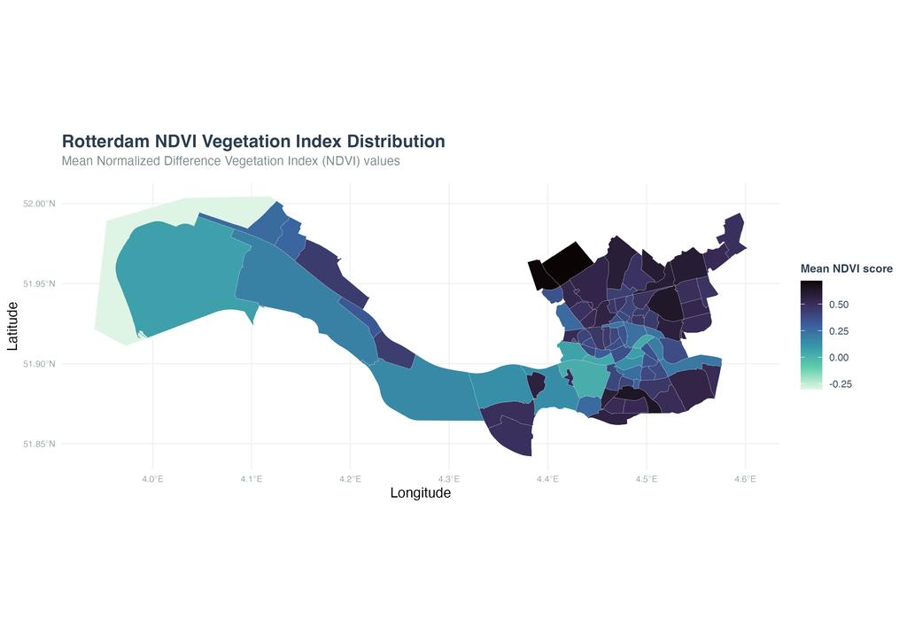

**Figure 1.** Rotterdam NDVI Vegetation Index Distribution

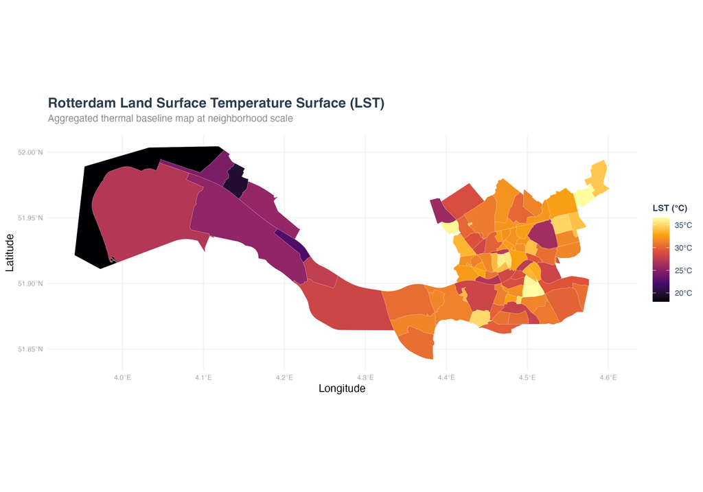

**Figure 2.** Rotterdam Land Surface Temperature (LST)

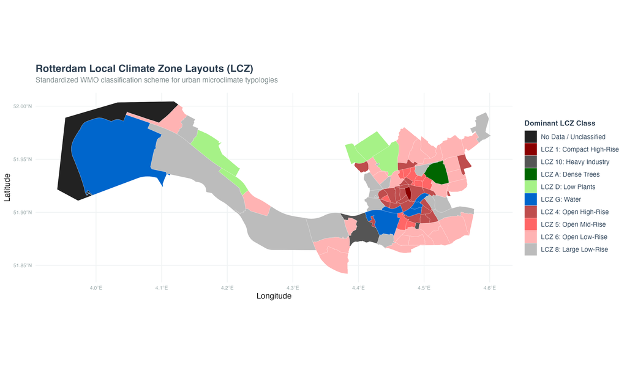

**Figure 3.** Rotterdam Local Climate Zone Layouts

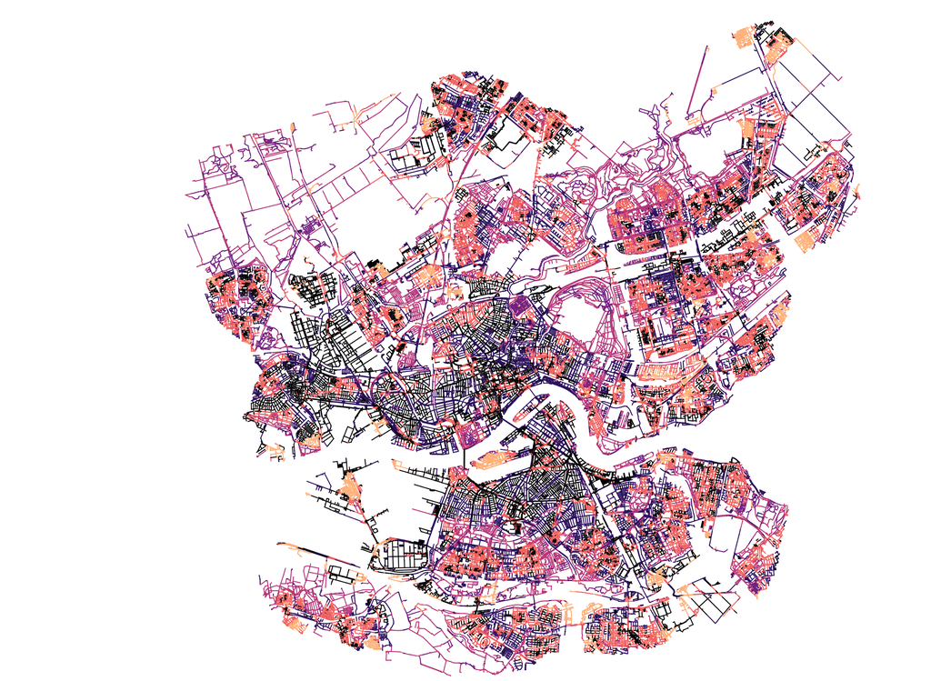

### Street-wise clustering

Relating LST, NDVI and PST

0. High LST / Low NDVI / Elevated PST

1. Medium LST / Medium NDVI / High PST

2. Low LST / High NDVI / Low PST

3. Low LST / Low NDVI / High PST

4. Medium LST / Medium NDVI / High PST

5. Medium LST / Medium NDVI / Low PST

From the analysis, three neighbourhoods stand out as showing extreme variation relative to the rest of the city: **Bloemhof, Afrikaanderwijk, and Hillesluis**.

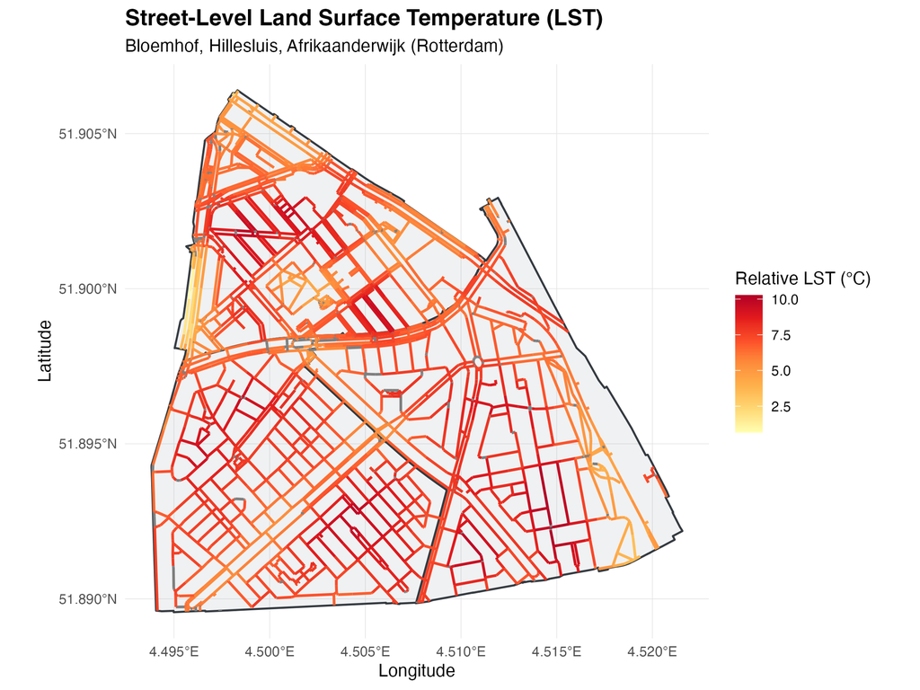

**Figure 5.** Rotterdam LST index street-wise Distribution

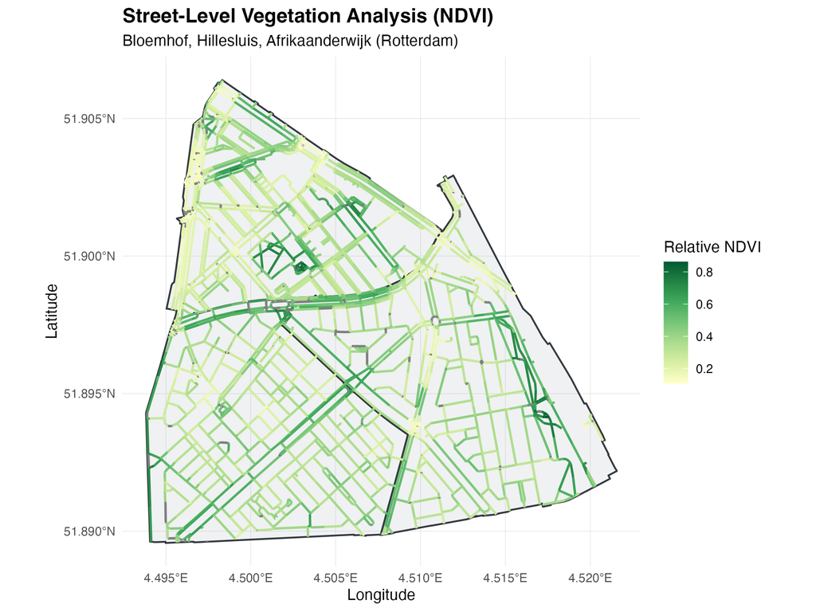

**Figure 6.** Rotterdam NDVI index street-wise Distribution

## Small-scale output: Guangzhou

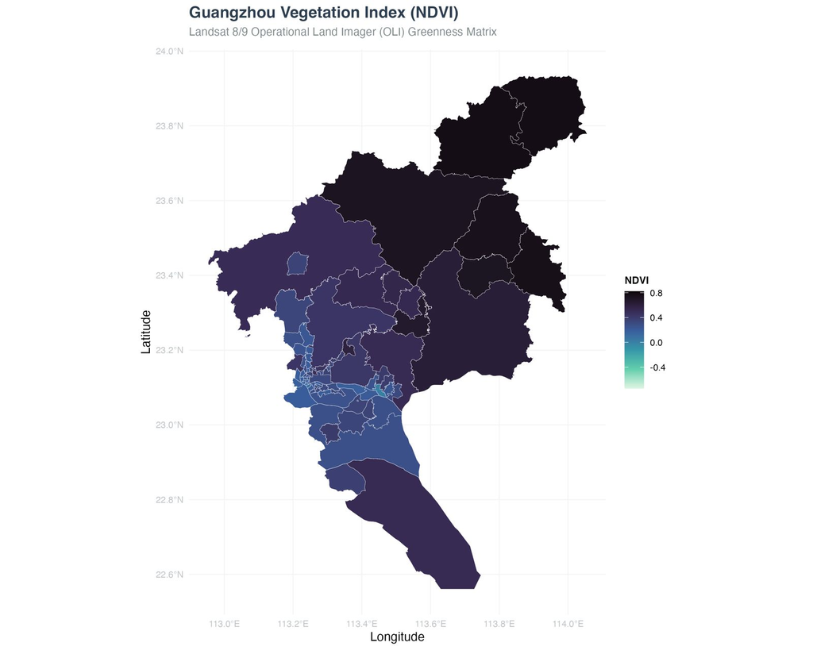

Figure 7. Guangzhou NDVI Vegetation Index Distribution

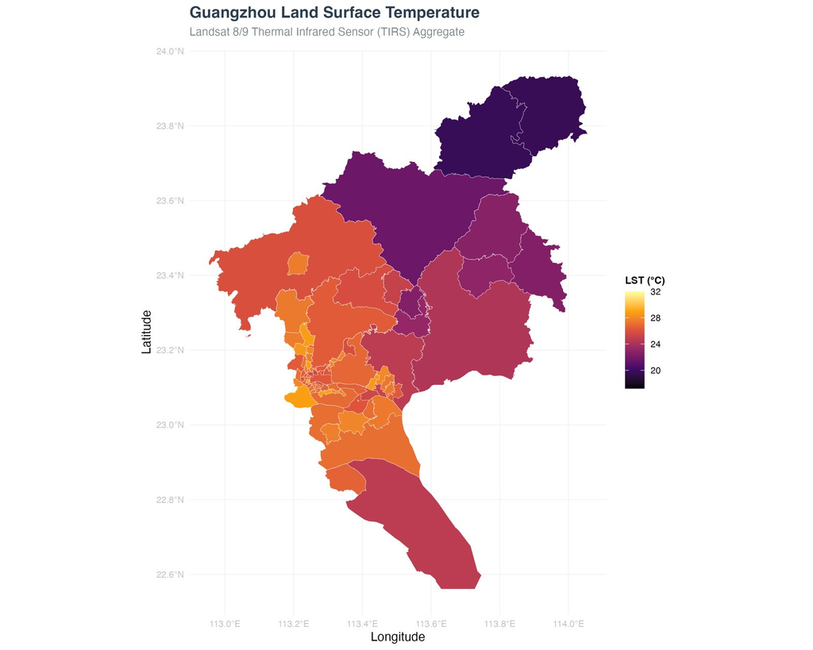

Figure 8. Guangzhou Land Surface Temperature (LST)

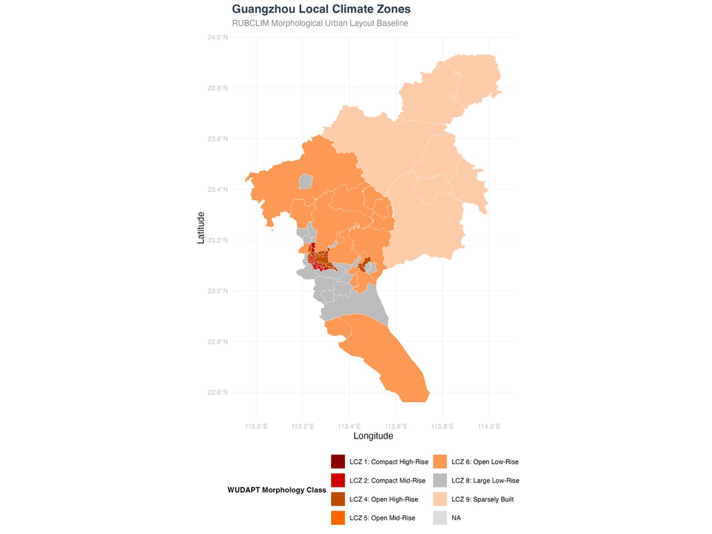

Figure 9. Guangzhou Local Climate Zone Layouts

# Results

## Rotterdam: Street-view and Nature based solutions

Street-level observations

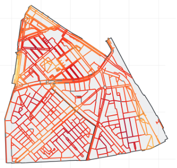

Click a dot to see street view

[figure not shown]

## Gunagzhou: Street-view and Nature based solutions

```r
library(sf)
library(dplyr)
library(plotly)

# Read the layer from the GeoPackage
invisible(capture.output(
  gzhou_roads_data <- st_read("data/guangzhou/guangzhou_roads_clustered.gpkg",
                        layer = "guangzhou_roads_data")
))

# Randomly select 500 rows
set.seed(42)  # remove or change this if you don't want reproducible sampling
gzhou_roads_sample <- gzhou_roads_data %>% slice_sample(n = 500)

# Colors for clusters 0-5
cluster_colors <- c(
  "0" = "#4C72B0",
  "1" = "#65C3A1",
  "2" = "#FC9964",
  "3" = "#869DC5",
  "4" = "#E597C0",
  "5" = "#D9C04C"
)

cluster3d_scaled <- plot_ly(
  x = gzhou_roads_sample$lst,
  y = gzhou_roads_sample$ndvi,
  z = gzhou_roads_sample$Bww1kM,
  type = "scatter3d",
  mode = "markers",
  color = as.factor(gzhou_roads_sample$cluster),
  colors = cluster_colors,
  marker = list(size = 3)
) %>%
  layout(
    title = "Street clusters in Guangzhou",
    scene = list(
      xaxis = list(title = "LST"),
      yaxis = list(title = "NDVI"),
      zaxis = list(title = "Betweenness")
    )
  )
cluster3d_scaled
```

[interactive chart not shown]

```r
# LST/NDVI correlation for Gzhou

library(plotly)

# Correlation coefficient
correlation <- cor(gzhou_roads_sample$lst, gzhou_roads_sample$ndvi, use = "complete.obs")

# Linear model for the trend line
lm_fit <- lm(ndvi ~ lst, data = gzhou_roads_sample)
lst_range <- seq(min(gzhou_roads_sample$lst, na.rm = TRUE),
                  max(gzhou_roads_sample$lst, na.rm = TRUE),
                  length.out = 100)
trend_pred <- predict(lm_fit, newdata = data.frame(lst = lst_range))

scatter_lst_ndvi <- plot_ly(
  data = gzhou_roads_sample,
  x = ~lst,
  y = ~ndvi,
  type = "scatter",
  mode = "markers",
  color = ~as.factor(cluster),
  colors = cluster_colors,
  marker = list(size = 6, opacity = 0.7),
  name = ~as.factor(cluster)
) %>%
  add_trace(
    x = lst_range,
    y = trend_pred,
    type = "scatter",
    mode = "lines",
    line = list(color = "#000000", width = 2, dash = "dash"),
    name = "Trend line",
    inherit = FALSE   # <-- prevents it from inheriting the marker settings above
  ) %>%
  layout(
    title = paste0("Guangzhou: LST vs NDVI (r = ", round(correlation, 3), ")"),
    xaxis = list(title = "LST"),
    yaxis = list(title = "NDVI")
  )

scatter_lst_ndvi
```

[interactive chart not shown]

```r
# LST/NDVI correlation for Rdam
library(plotly)

# Correlation coefficient
correlation <- cor(roads_sample$lst, roads_sample$ndvi, use = "complete.obs")

# Linear model for the trend line
lm_fit <- lm(ndvi ~ lst, data = roads_sample)
lst_range <- seq(min(roads_sample$lst, na.rm = TRUE),
                  max(roads_sample$lst, na.rm = TRUE),
                  length.out = 100)
trend_pred <- predict(lm_fit, newdata = data.frame(lst = lst_range))

scatter_lst_ndvi <- plot_ly(
  data = roads_sample,
  x = ~lst,
  y = ~ndvi,
  type = "scatter",
  mode = "markers",
  color = ~as.factor(cluster),
  colors = cluster_colors,
  marker = list(size = 6, opacity = 0.7),
  name = ~as.factor(cluster)
) %>%
  add_trace(
    x = lst_range,
    y = trend_pred,
    type = "scatter",
    mode = "lines",
    line = list(color = "#000000", width = 2, dash = "dash"),
    name = "Trend line",
    inherit = FALSE   # <-- prevents it from inheriting the marker settings above
  ) %>%
  layout(
    title = paste0("Rotterdam: LST vs NDVI (r = ", round(correlation, 3), ")"),
    xaxis = list(title = "LST"),
    yaxis = list(title = "NDVI")
  )

scatter_lst_ndvi
```

[interactive chart not shown]

```r
library(sf)
library(dplyr)
library(plotly)

# Compute % of total segment length per cluster for one roads dataset
cluster_length_pct <- function(roads_data, all_clusters = names(cluster_colors)) {
  roads_data$seg_length <- as.numeric(st_length(roads_data))

  pct_df <- roads_data %>%
    st_drop_geometry() %>%
    mutate(cluster = as.character(cluster)) %>%
    group_by(cluster) %>%
    summarise(total_length = sum(seg_length, na.rm = TRUE), .groups = "drop") %>%
    mutate(pct = 100 * total_length / sum(total_length))

  tibble(cluster = all_clusters) %>%
    left_join(pct_df, by = "cluster") %>%
    mutate(pct = ifelse(is.na(pct), 0, pct))
}

# Build a grouped bar chart: cities on shared x-axis, bars colored by cluster
# data_list: named list, e.g. list(Rotterdam = roads_data, Guangzhou = gzhou_roads_data)
plot_cluster_bar <- function(data_list, colors = cluster_colors) {
  combined_df <- bind_rows(
    lapply(names(data_list), function(city_name) {
      cluster_length_pct(data_list[[city_name]]) %>%
        mutate(city = city_name)
    })
  )

  plot_ly(
    data = combined_df,
    x = ~city,
    y = ~pct,
    color = ~cluster,
    colors = colors,
    type = "bar"
  ) %>%
    layout(
      title = "% of total road segment length by cluster",
      xaxis = list(title = ""),
      yaxis = list(title = "% of total length", ticksuffix = "%"),
      barmode = "group",
      legend = list(title = list(text = "Cluster"))
    )
}

bar_chart <- plot_cluster_bar(
  list(Rotterdam = roads_data, Guangzhou = gzhou_roads_data)
)
bar_chart
```

[interactive chart not shown]